# Homework 00 - STAT 432

Kevin Wong - kjwong2

Due: Friday, January 26, 11:59 PM

Please see the [homework policy document](https://daviddalpiaz.github.io/stat432sp18/homework_policy.html) for detailed instructions and some grading notes. Failure to follow instructions will result in point reductions.

The purpose of this homework is to make you familiar with homework procedure. It will not count towards your final grade. A score of `1` will indicate that you have followed all procedures correctly. A score of `0` will indicate that you have failed to follow all directions. It will not be graded for correctness, but solutions will be posted.

## Exercise 1

For this exercise, we will use the `diabetes` dataset from the `faraway` package.

**(a)** Install and load the `faraway` package. **Do not** include the installation command in your `.Rmd` file. (If you do it will install the package every time you knit your file.) **Do** include the command to load the package into your environment.

**Solution:**

```r
library(faraway)
```

**(b)** Coerce the data to be a tibble instead of a data frame. (You will need the `tibble` package to do so.) How many observations are in this dataset? How many variables? Who are the individuals in this dataset?

**Solution:**

```r
library(tibble)
diabetes_data = as_tibble(diabetes)
```

- There are 403 observations and 19 variables. The individuals in this data set are poeple with diabetes.

**(c)** What is the mean [HDL](https://en.wikipedia.org/wiki/High-density_lipoprotein) level (High Density Lipoprotein) of individuals in this sample?

**Solution:**

```r
mean(diabetes_data$hdl, na.rm = TRUE)
```

```
## [1] 50.44527
```

**(d)** What is the mean HDL of females in this sample?

**Solution:**

```r
fem_diab = subset(diabetes, gender == "female", na.rm = TRUE)
mean(fem_diab$hdl)
```

```
## [1] 52.11111
```

**(e)** Create a scatter plot of total cholesterol (y-axis) vs weight (x-axis). Use a non-default color for the points. (Also, be sure to give the plot a title and label the axes appropriately.) Based on the scatter plot, does there seem to be a relationship between the two variables? Briefly explain.

**Solution:**

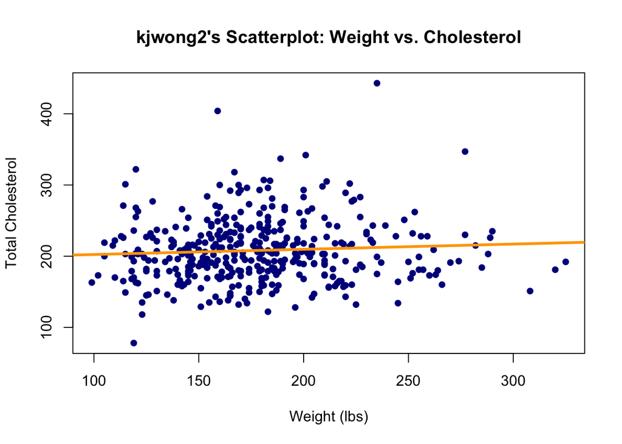

```r
chweightmod = lm(chol ~ weight, data = diabetes)
plot(chol ~ weight, data = diabetes, xlab = "Weight (lbs)", ylab = "Total Cholesterol", main = "kjwong2's Scatterplot: Weight vs. Cholesterol", col = "darkblue", pch = 16)
abline(chweightmod, lwd = 3, col = "orange")
```

**(f)** Create side-by-side boxplots for HDL by gender. Use non-default colors for the plot. (Also, be sure to give the plot a title and label the axes appropriately.) Based on the boxplot, does there seem to be a difference in HDL level between the genders.? Briefly explain.

**Solution:**

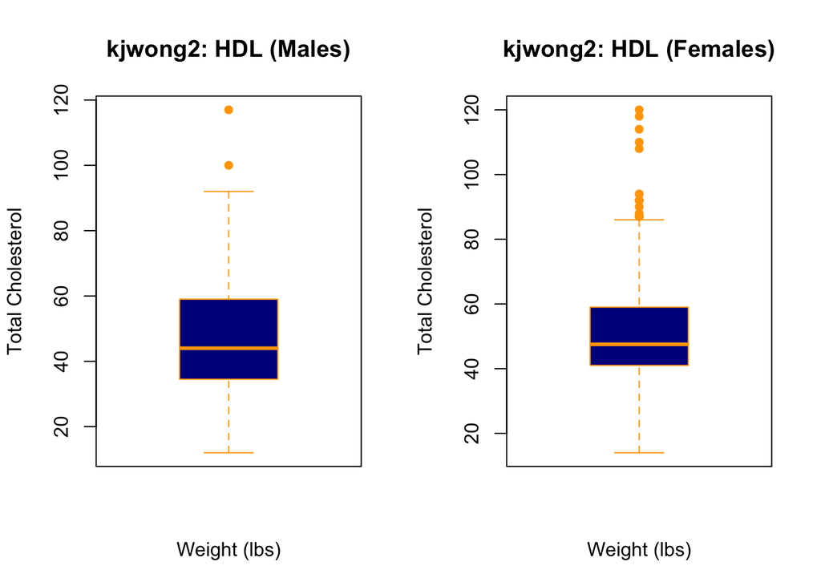

```r
male_diab = subset(diabetes, gender == "male", na.rm = TRUE)
par(mfrow = c(1, 2))
boxplot(male_diab$hdl, data = diabetes, xlab = "Weight (lbs)", ylab = "Total Cholesterol", main = "kjwong2: HDL (Males)", col = "darkblue", border = "orange", pch = 16)
boxplot(fem_diab$hdl, data = diabetes, xlab = "Weight (lbs)", ylab = "Total Cholesterol", main = "kjwong2: HDL (Females)", col = "darkblue", border = "orange", pch = 16)
```

## Exercise 2

For this exercise we will use the data stored in `nutrition.csv`. It contains the nutritional values per serving size for a large variety of foods as calculated by the USDA. It is a cleaned version totaling 5138 observations and is current as of September 2015.

The variables in the dataset are:

- `ID`
- `Desc` - Short description of food
- `Water` - in grams
- `Calories` - in kcal
- `Protein` - in grams
- `Fat` - in grams
- `Carbs` - Carbohydrates, in grams
- `Fiber` - in grams
- `Sugar` - in grams
- `Calcium` - in milligrams
- `Potassium` - in milligrams
- `Sodium` - in milligrams
- `VitaminC` - Vitamin C, in milligrams
- `Chol` - Cholesterol, in milligrams
- `Portion` - Description of standard serving size used in analysis

**(a)** Create a histogram of `Calories`. Do not modify `R`’s default bin selection. Make the plot presentable. Describe the shape of the histogram. Do you notice anything unusual?

**Solution:**

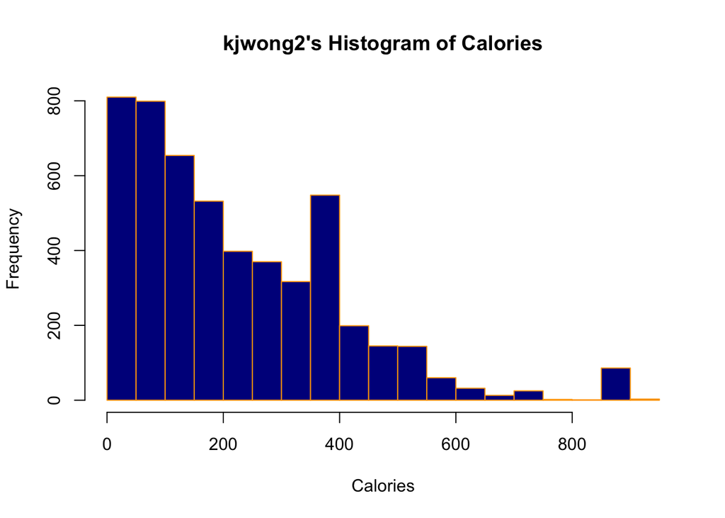

```r
nutdata = read.csv("nutrition.csv")
hist(nutdata$Calories, xlab = "Calories", main = "kjwong2's Histogram of Calories", border = "orange", col = "darkblue")
```

- The histogram is skewed right.

**(b)** Create a scatter plot of `Calories` (y-axis) vs `4 * Protein + 4 * Carbs + 9 * Fat + 2 * Fiber` (x-axis). Make the plot presentable. You will either need to add a new variable to the data frame, or, use the `I()` function in your formula in the call to `plot()`. If you are at all familiar with nutrition, you may realize that this formula calculates the calorie count based on the protein, carbohydrate, and fat values. You’d expect then that the result here is a straight line. Is it? If not, can you think of any reasons why it is not?

**Solution:**

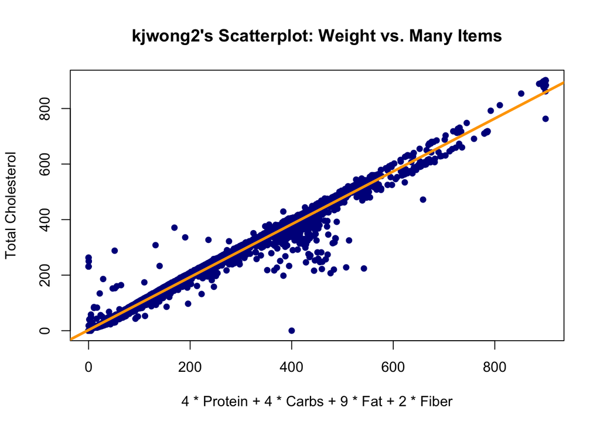

```r
items = 4 * nutdata$Protein + 4 * nutdata$Carbs + 9 * nutdata$Fat + 2 * nutdata$Fiber
calmodel = lm(Calories ~ items, data = nutdata)
plot(Calories ~ items, data = nutdata, xlab = "4 * Protein + 4 * Carbs + 9 * Fat + 2 * Fiber", ylab = "Total Cholesterol", main = "kjwong2's Scatterplot: Weight vs. Many Items", col = "darkblue", pch = 16)
abline(calmodel, lwd = 3, col = "orange")
```

## Exercise 3

For each of the following parts, use the following vectors:

```r
a = 1:10
b = 10:1
c = rep(1, times = 10)
d = 2 ^ (1:10)
```

**(a)** Write a function called `sum_of_squares`.

- Arguments:
  - A vector of numeric data `x`.
- Output:
  - The sum of the squares of the elements of the vector. $\sum_{i = 1}^n x_i^2$

Provide your function, as well as the result of running the following code:

**Solution:**

```r
sum_of_squares = function(x) {
  sum(x^2)
}
```

```r
sum_of_squares(x = a)
sum_of_squares(x = c(c, d))
```

[output not shown]

**(b)** Write a function called `rms_diff`.

- Arguments:
  - A vector of numeric data `x`.
  - A vector of numeric data `y`.
- Output:
  - $\sqrt{\frac{1}{n}\sum_{i = 1}^n (x_i - y_i)^{2}}$

If the vectors have different lengths, the shorter vector should be repeated until it matches the length of the longer vector.

Provide your function, as well as the result of running the following code:

**Solution:**

```r
rms_diff = function(x, y) {
  sqrt(sum(x-y)^2)
}
```

```r
rms_diff(x = a, y = b)
rms_diff(x = d, y = c)
rms_diff(x = d, y = 1)
rms_diff(x = a, y = 0) ^ 2 * length(a)
```

[output not shown]